# Shaping Future Transport Systems

Shared micromobility challenges and opportunities

Author

weemuk

*“Shared micromobility schemes, such as shared bikes and e-scooters, offer a flexible transport option for short-distance trips by allowing access to micromobility on an as needed basis. These schemes have the potential to contribute to transport sustainability, for example, by promoting transport equity if they are priced affordably and offer alternatives for people with limited mobility resources or for those living in areas with poor accessibility. However, they can also reinforce existing inequities when infrastructure, pricing, deployment, or patterns of use favour certain groups or areas, or when users experience unequal benefits despite having similar access, which can in turn hinder progress towards a more sustainable transport system.”*

**Using evidence, discuss the challenges and opportunities that shared micromobility schemes present in relation to transport equity, and how these schemes should develop to support a more equitable transport system.**

The schemes of shared micromobility, a service that is present for around half a century, has sharply increased worldwide with the exploded popularity of app-based shared bike, dockless e-scooters and e-bicycles programs (Brown and Howell 2025). These systems assured a variety of urban benefits, including ‘flexible mobility, emission reductions, physical activity benefits, reduced congestion and fuel use, individual financial savings and support for multimodal transport connections’ (Fishman, Washington, and Haworth 2012, 686). As a result, shared micromobility offer a potential solution to bridge the gaps in existing transport poverty by connecting users to public transportation services.

However, the distribution of these services is not automatically accessible to all users. The policy and regulation capacity has been outpaced by the rapid growth of shared micromobility services, making it difficult to provide accessibility for all residents. The potential that shared micromobility have in order to combat transport and accessibility poverty will be addressed in three key opportunities: use of electric micromobility to reduce physical limitations, implement specific policies to ensure socio-demographic and spatial equity, and adapting shared micromobility to the context of developing countries.

One opportunity lies in the continued implementation of technology. Traditional bike-sharing systems, while beneficial, have highlighted the challenge of making them inclusive. As Guan et al. emphasises, users of conventional bike-sharing systems tend to be mostly men, young, with higher levels of education and income (Guan et al. 2024). Hence, a segment of the population, including minorities, women, and older adults, has been excluded. The growing use of shared electric micromobility, such as e-bikes, e-scooters and e-mopeds, directly addresses this issue. Therefore, by requiring less physical effort and offering greater speed, these electric options significantly increase users’ autonomy.

For this reason, shared e-scooter users can be considered more representative of the population compared to traditional bikeshare members (Guan et al. 2024).This technological implementation is fundamental to reduce physical barriers and makes shared micromobility an alternative for users with physical limitations, age, safety or trip distance concerns. However, for its effective implementation, governments must ‘introduce new policies related to maximum speeds, the mandatory use of bike infrastructure [and] the need for designated parking in service areas’ (Zakhem and Smith-Colin 2021).

Besides the physical barrier to use the shared micromobility services, there are socioeconomic and spatial gaps that prevent equity in these mobility schemes. To achieve a scenario where services benefit users equitably, it is essential to identify disadvantaged groups and implement targeted policies to improve their current situation. In this regard, the socioeconomic factor is an important barrier. Currently, many shared micromobility schemes rely on app-based and credit cards payments, leading to the exclusion to potential unbanked and low-income users. Some authorities are aware of this situation and have started requiring operators to offer smartphone alternatives and cash payment options (Brown and Howell 2025). Furthermore, the price itself is a barrier for low-income residents. The implementation of regulatory policies can reduce the current gap by offering a wide range of options to groups identified as low-income users (e.g. 30 minutes free rides or 50% fare reduction) (Brown and Howell 2024).

Moreover, spatial inequity represents another obstacle to shared micromobility accessibility. Without the planification of bikeshare stations, and especially the vehicle fleets of dockless schemes, these services tend to concentrate in affluent, centric, or high-density areas, leaving users underserved with low connectivity who could potentially benefit the most (Brown and Howell 2024). A way to mitigate this is through city authorities, which, as part of policy regulations, can require operators to allocate a fixed percentage of their fleet or stations to identified low-income or underserved areas. However, this distribution and these specifications must be properly studied for each context. A study from Su et al., has identified that ‘low-income neighbourhoods have a relatively higher demand for shared bikes but not for shared e-scooters’ (Su, Yan, and Zhao 2024, 33). This finding highlights that behaviour and decisions from the users must be considered when planning shared micromobility regulations. It also underscores the necessity of data-driven decision making.

Data collection from shared micromobility operators can be indispensable for its successful regulation. Governments can require operators to share anonymized user information to make a range of data-driven decisions. This data allows city authorities to understand user needs, identify service gaps, and develop solutions to reduce inequity. Furthermore, data can bring opportunities for decisions related to emissions, scarce travel connectivity, and accessibility (Brown and Howell 2024). In that regard, the use of data can drive improvements in the equity and accessibility of shared micromobility services.

This potential for an equitable, data-driven approach is particularly evident in cities in developing countries, especially in Latin America. These cities present a different context than those in North America or Europe. The World Resources Institute depicts that car ownership in Latin America is drastically lower, and in average a 70% less than in the United States (2024). Also, as shown in figure 1, the primary modes of transport in Latin America cities are walking and public transport. In this context, shared micromobility is not competing with the private car, but rather reinforces existing modes of transport (walking and public transport) and presents itself as an alternative for longer trips, potentially replacing the car use in this scenario. This presents an enormous opportunity, where it must be considered that the main challenge for accessibility in Latin American cities is connectivity and equitable distribution in the city, from the periphery to the urban centre, often compromised by a history of informal, unsafe, or unreliable transportation system.

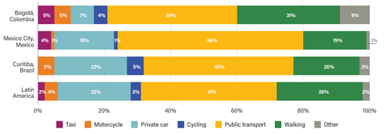

Figure 1: Main modes of transport in Latin America (World Resources Institute, 2024)

In conclusion, the rapid growth of shared micromobility services represents an alternative in urban mobility, offering flexibility and reduced emissions. However, this growth has created some inequalities because the service has been prioritised for certain sectors of society and promoting a shared micromobility equity relies on the actions and regulations made by city authorities. This can be achieved by developing accessible regulations for the implementation of electric vehicles (e.g. e-scooters, e-bikes and e-mopeds) as an alternative to reduce physical limitation to users. Also, applying specific policies for socioeconomic and spatial equity with a data-driven approach can led governments to implement a more accessible service. Lastly, shared micromobility schemes must be analysed within the political and social context to assess potential opportunities for more equitable services.

## References

Brown, Anne, and Amanda Howell. 2024. “Mobility for the People: Equity Requirements in US Shared Micromobility Programs.” *Journal of Cycling and Micromobility Research* 2 (December): 100020. https://doi.org/10.1016/j.jcmr.2024.100020.

———. 2025. “From Paper to Practice: Shared Micromobility Equity Policies Yield Mixed Outcomes.” *Transportation Research Interdisciplinary Perspectives* 31 (May): 101480. https://doi.org/10.1016/j.trip.2025.101480.

Fishman, Elliot, Simon Washington, and Narelle Haworth. 2012. “Barriers and Facilitators to Public Bicycle Scheme Use: A Qualitative Approach.” *Transportation Research Part F: Traffic Psychology and Behaviour* 15 (6): 686–98. https://doi.org/10.1016/j.trf.2012.08.002.

Guan, Xiaodong, Dea van Lierop, Zihao An, Eva Heinen, and Dick Ettema. 2024. “Shared Micro-Mobility and Transport Equity: A Case Study of Three European Countries.” *Cities* 153 (October): 105298. https://doi.org/10.1016/j.cities.2024.105298.

Su, Lin, Xiang Yan, and Xilei Zhao. 2024. “Spatial Equity of Micromobility Systems: A Comparison of Shared E-Scooters and Docked Bikeshare in Washington DC.” *Transport Policy* 145 (January): 25–36. https://doi.org/10.1016/j.tranpol.2023.10.008.

Zakhem, Myriam, and Janille Smith-Colin. 2021. “Micromobility Implementation Challenges and Opportunities: Analysis of e-Scooter Parking and High-Use Corridors.” *Transportation Research Part D: Transport and Environment* 101 (December): 103082. https://doi.org/10.1016/j.trd.2021.103082.